# DATA PREPROCESSING

## 1. Thông tin cá nhân

Họ và tên: Đặng Triệu Kha  
Mã số sinh viên: 22127476  
Lớp học phần: 22KHMT1

## 2. Tự đánh giá

| STT | Chi tiết | Tự đánh giá mức độ hoàn thành |
| --- | --- | --- |
| 1 | Data cleaning | 100 % |
| 2 | Dimensionality Reduction/Feature selection | 100 % |
| 3 | Data Normalization | 100 % |
| 4 | Data Discretization | 100 % |

## 3. Tải dữ liệu

**Cần tải thêm thư viện ucimlrepo để tải dữ liệu online**

```python
! pip install ucimlrepo
```

[output not shown]

**Các thư viện cần sử dụng**

```python
from ucimlrepo import fetch_ucirepo
import numpy as np
import pandas as pd
import matplotlib.pyplot as plt
import seaborn as sns
# fetch dataset
```

```python
adult = fetch_ucirepo(id=2)

# data (as pandas dataframes)
X = adult.data.features
y = adult.data.targets
```

```python
X
```

|  | age | workclass | fnlwgt | education | education-num | marital-status | occupation | relationship | race | sex | capital-gain | capital-loss | hours-per-week | native-country |
| --- | --- | --- | --- | --- | --- | --- | --- | --- | --- | --- | --- | --- | --- | --- |
| 0 | 39 | State-gov | 77516 | Bachelors | 13 | Never-married | Adm-clerical | Not-in-family | White | Male | 2174 | 0 | 40 | United-States |
| 1 | 50 | Self-emp-not-inc | 83311 | Bachelors | 13 | Married-civ-spouse | Exec-managerial | Husband | White | Male | 0 | 0 | 13 | United-States |
| 2 | 38 | Private | 215646 | HS-grad | 9 | Divorced | Handlers-cleaners | Not-in-family | White | Male | 0 | 0 | 40 | United-States |
| 3 | 53 | Private | 234721 | 11th | 7 | Married-civ-spouse | Handlers-cleaners | Husband | Black | Male | 0 | 0 | 40 | United-States |
| 4 | 28 | Private | 338409 | Bachelors | 13 | Married-civ-spouse | Prof-specialty | Wife | Black | Female | 0 | 0 | 40 | Cuba |
| ... | ... | ... | ... | ... | ... | ... | ... | ... | ... | ... | ... | ... | ... | ... |
| 48837 | 39 | Private | 215419 | Bachelors | 13 | Divorced | Prof-specialty | Not-in-family | White | Female | 0 | 0 | 36 | United-States |
| 48838 | 64 | NaN | 321403 | HS-grad | 9 | Widowed | NaN | Other-relative | Black | Male | 0 | 0 | 40 | United-States |
| 48839 | 38 | Private | 374983 | Bachelors | 13 | Married-civ-spouse | Prof-specialty | Husband | White | Male | 0 | 0 | 50 | United-States |
| 48840 | 44 | Private | 83891 | Bachelors | 13 | Divorced | Adm-clerical | Own-child | Asian-Pac-Islander | Male | 5455 | 0 | 40 | United-States |
| 48841 | 35 | Self-emp-inc | 182148 | Bachelors | 13 | Married-civ-spouse | Exec-managerial | Husband | White | Male | 0 | 0 | 60 | United-States |

48842 rows × 14 columns

```python
y
```

|  | income |
| --- | --- |
| 0 | <=50K |
| 1 | <=50K |
| 2 | <=50K |
| 3 | <=50K |
| 4 | <=50K |
| ... | ... |
| 48837 | <=50K. |
| 48838 | <=50K. |
| 48839 | <=50K. |
| 48840 | <=50K. |
| 48841 | >50K. |

48842 rows × 1 columns

## 3. Data cleaning - Làm sạch dữ liệu

### 3.1 Assessment of Missing Data - Xử lí dữ liệu bị thiếu

**Quan sát tổng quan các dữ liệu bị thiếu trong dataframe**

```python
X.isna().sum()
```

```
age                 0
workclass         963
fnlwgt              0
education           0
education-num       0
marital-status      0
occupation        966
relationship        0
race                0
sex                 0
capital-gain        0
capital-loss        0
hours-per-week      0
native-country    274
dtype: int64
```

Các cột `workclass`, `occupation`, `native-country` bị thiếu dữ liệu. Việc xử lí thiếu dữ liệu đối với mỗi thuộc tính là khác nhau và được trình bày bên dưới.

#### 3.1.1 Xử lí đối với thuộc tính native-country

Phân phối dữ liệu của thuộc tính `native-country`:

```python
X['native-country'].value_counts()
```

```
native-country
United-States                 43832
Mexico                          951
?                               583
Philippines                     295
Germany                         206
Puerto-Rico                     184
Canada                          182
El-Salvador                     155
India                           151
Cuba                            138
England                         127
China                           122
South                           115
Jamaica                         106
Italy                           105
Dominican-Republic              103
Japan                            92
Guatemala                        88
Poland                           87
Vietnam                          86
Columbia                         85
Haiti                            75
Portugal                         67
Taiwan                           65
Iran                             59
Greece                           49
Nicaragua                        49
Peru                             46
Ecuador                          45
France                           38
Ireland                          37
Hong                             30
Thailand                         30
Cambodia                         28
Trinadad&Tobago                  27
Laos                             23
Yugoslavia                       23
Outlying-US(Guam-USVI-etc)       23
Scotland                         21
Honduras                         20
Hungary                          19
Holand-Netherlands                1
Name: count, dtype: int64
```

```python
percent_native_country_miss = (X['native-country'].isna().sum() + X[X['native-country'] == '?'].shape[0])/X.shape[0]
percent_native_country_miss
```

```
0.017546374022357807
```

```python
# Điền mode cho cột native-country
X.loc[:,'native-country'] = X['native-country'].fillna(X['native-country'].mode()[0])
#X[X['native-country'] == "?"] = X['native-country'].mode()[0]
```

##### a. Phân loại dữ liệu thành 2 tập bị thiếu và không bị thiếu theo từng thuộc tính

Trong 2 featrue `workclass`,`occupation` có những dòng có giá trị là "?". Nguyên nhân có thể do quá trình thu thập đã không thu thập được thông tin về 2 thuộc tính này. Tôi sẽ đối xử với các dòng có giá trị "?" giống với các dòng có giá trị NaN

```python
X.loc[X['workclass'] == '?', 'workclass'] = np.nan
X.loc[X['occupation'] == '?', 'occupation'] = np.nan
```

```python
# Tạo tập dữ liệu chứa các hàng có và không có giá trị thiếu cho occupation và workclass
occupation_missing = X[X['occupation'].isnull()]
occupation_not_missing = X[X['occupation'].notnull()]

workclass_missing = X[X['workclass'].isnull()]
workclass_not_missing = X[X['workclass'].notnull()]
```

```python
occupation_missing
```

|  | age | workclass | fnlwgt | education | education-num | marital-status | occupation | relationship | race | sex | capital-gain | capital-loss | hours-per-week | native-country |
| --- | --- | --- | --- | --- | --- | --- | --- | --- | --- | --- | --- | --- | --- | --- |
| 27 | 54 | NaN | 180211 | Some-college | 10 | Married-civ-spouse | NaN | Husband | Asian-Pac-Islander | Male | 0 | 0 | 60 | South |
| 61 | 32 | NaN | 293936 | 7th-8th | 4 | Married-spouse-absent | NaN | Not-in-family | White | Male | 0 | 0 | 40 | ? |
| 69 | 25 | NaN | 200681 | Some-college | 10 | Never-married | NaN | Own-child | White | Male | 0 | 0 | 40 | United-States |
| 77 | 67 | NaN | 212759 | 10th | 6 | Married-civ-spouse | NaN | Husband | White | Male | 0 | 0 | 2 | United-States |
| 106 | 17 | NaN | 304873 | 10th | 6 | Never-married | NaN | Own-child | White | Female | 34095 | 0 | 32 | United-States |
| ... | ... | ... | ... | ... | ... | ... | ... | ... | ... | ... | ... | ... | ... | ... |
| 48682 | 61 | NaN | 265201 | Some-college | 10 | Married-civ-spouse | NaN | Husband | White | Male | 0 | 0 | 14 | United-States |
| 48769 | 21 | NaN | 212661 | Some-college | 10 | Never-married | NaN | Own-child | White | Female | 0 | 0 | 30 | United-States |
| 48800 | 73 | NaN | 144872 | HS-grad | 9 | Married-civ-spouse | NaN | Husband | White | Male | 0 | 0 | 25 | Canada |
| 48812 | 81 | NaN | 26711 | Assoc-voc | 11 | Married-civ-spouse | NaN | Husband | White | Male | 2936 | 0 | 20 | United-States |
| 48838 | 64 | NaN | 321403 | HS-grad | 9 | Widowed | NaN | Other-relative | Black | Male | 0 | 0 | 40 | United-States |

2809 rows × 14 columns

##### b. Xây dựng mô hình dự đoán giá trị bị thiếu (dựa vào một số cột đã biết)

```python
# Tạo một hàm để dự đoán giá trị dựa trên các thuộc tính quan trọng
def impute_missing_values(df_missing, df_not_missing, target_column, reference_columns):
    # Điền giá trị mode từ các nhóm được phân loại theo các cột liên quan
    for _, row in df_missing.iterrows():
        # Tạo mask cho các hàng trong df_not_missing có các thuộc tính giống với hàng đang xét của df_missing
        mask = (df_not_missing[reference_columns] == row[reference_columns].values).all(axis=1)

        # Kiểm tra nếu có hàng nào thỏa mãn mask, nếu có, lấy giá trị mode từ cột target_column
        if df_not_missing[mask].shape[0] > 0:
            df_missing.loc[row.name, target_column] = df_not_missing[mask][target_column].mode()[0]
        else:
            # Nếu không có hàng nào khớp, điền mode của toàn bộ cột
            df_missing.loc[row.name, target_column] = df_not_missing[target_column].mode()[0]

    return df_missing
```

##### c. Điền giá trị bị thiếu

Tôi cho rằng các thuộc tính `education`,`education-num`, `age`, `sex`, `hours-per-week` sẽ liên quan đến thuộc tính `occupation` và `workclass` nên sẽ dự đoán giá trị bị thiếu ở 2 thuộc tính này dựa trên các thuộc tính trên.

```python
# Điền giá trị thiếu cho occupation và workclass

occupation_missing = impute_missing_values(occupation_missing, occupation_not_missing,
                                           'occupation', ['education', 'education-num', 'age', 'sex', 'hours-per-week'])

workclass_missing = impute_missing_values(workclass_missing, workclass_not_missing,
                                          'workclass', ['education', 'education-num', 'age', 'sex', 'hours-per-week'])

# Gộp lại dữ liệu đã điền với dữ liệu ban đầu

X.update(occupation_missing)
X.update(workclass_missing)
```

##### d. Kiểm tra lại việc thiếu dữ liệu

```python
print("Số lượng giá trị thiếu sau khi điền:")
print(X.isna().sum())
```

```
Số lượng giá trị thiếu sau khi điền:
age               0
workclass         0
fnlwgt            0
education         0
education-num     0
marital-status    0
occupation        0
relationship      0
race              0
sex               0
capital-gain      0
capital-loss      0
hours-per-week    0
native-country    0
dtype: int64
```

### 3.2 Identification of Duplicate Records - Xác định dữ liệu trùng lặp

#### a. Xác định các dòng bị trùng lặp

**Chỉ số các dòng bị trùng lặp**

```python
X_y = pd.concat((X,y), axis= 1)
id = X_y[X_y.duplicated()].index
id
```

```
Index([ 4881,  5104,  9171, 11631, 11825, 13084, 15059, 17040, 18555, 18698,
       21318, 21490, 21875, 22300, 22367, 22494, 25872, 26313, 28230, 28522,
       28846, 29157, 30845, 31993, 32404, 33425, 43750, 43773, 46409, 47284,
       48521],
      dtype='int64')
```

#### b. Xoá các dòng trùng lặp

```python
print('Số dòng trong X trước khi xoá:', len(X))
print('Số dòng trong X trước khi xoá:', len(y))
```

```
Số dòng trong X trước khi xoá: 48842
Số dòng trong X trước khi xoá: 48842
```

```python
X = X.drop(id)
y = y.drop(id)
```

```python
print('Số dòng trong X sau khi xoá:', len(X))
print('Số dòng trong X sau khi xoá:', len(y))
```

```
Số dòng trong X sau khi xoá: 48811
Số dòng trong X sau khi xoá: 48811
```

### 3.3 Additional Data Cleaning Methods - Các phương thức làm sạch dữ liệu khác

Tôi sẽ thực hiện encode các thuộc tính phân loại (categorical feature)

#### 3.3.1 Thực hiện encoding feature `sex`

```python
X['is Male'] = np.where(X['sex'] == 'Male', 1, 0)
X[['sex', 'is Male']]
```

|  | sex | is Male |
| --- | --- | --- |
| 0 | Male | 1 |
| 1 | Male | 1 |
| 2 | Male | 1 |
| 3 | Male | 1 |
| 4 | Female | 0 |
| ... | ... | ... |
| 48837 | Female | 0 |
| 48838 | Male | 1 |
| 48839 | Male | 1 |
| 48840 | Male | 1 |
| 48841 | Male | 1 |

48811 rows × 2 columns

#### 3.3.2 Thực hiện encoding feature `marital-status`

```python
X['marital-status'].value_counts()
```

```
marital-status
Married-civ-spouse       22372
Never-married            16097
Divorced                  6629
Separated                 1530
Widowed                   1518
Married-spouse-absent      628
Married-AF-spouse           37
Name: count, dtype: int64
```

Thực hiện `one-hot encoding` thế nhưng gom 3 cột "Married-civ-spouse", "Married-spouse-absent", "Married-AF-spouse" thành 1 cột "Married". Cụ thể như sau:

```python
X['Married'] = np.where((X['marital-status'] == 'Married-civ-spouse') | (X['marital-status'] == 'Married-spouse-absent') | (X['marital-status'] =='Married-AF-spouse'),1,0)
X['Never-married'] = np.where((X['marital-status'] =='Never-married' ),1,0)
X['Separated'] = np.where((X['marital-status'] =='Separated' ),1,0)
X['Widowed'] = np.where((X['marital-status'] =='Widowed' ),1,0)
X['Divorced'] = np.where((X['marital-status'] =='Divorced' ),1,0)
```

```python
X[['marital-status','Married','Never-married','Separated','Widowed','Divorced']]
```

|  | marital-status | Married | Never-married | Separated | Widowed | Divorced |
| --- | --- | --- | --- | --- | --- | --- |
| 0 | Never-married | 0 | 1 | 0 | 0 | 0 |
| 1 | Married-civ-spouse | 1 | 0 | 0 | 0 | 0 |
| 2 | Divorced | 0 | 0 | 0 | 0 | 1 |
| 3 | Married-civ-spouse | 1 | 0 | 0 | 0 | 0 |
| 4 | Married-civ-spouse | 1 | 0 | 0 | 0 | 0 |
| ... | ... | ... | ... | ... | ... | ... |
| 48837 | Divorced | 0 | 0 | 0 | 0 | 1 |
| 48838 | Widowed | 0 | 0 | 0 | 1 | 0 |
| 48839 | Married-civ-spouse | 1 | 0 | 0 | 0 | 0 |
| 48840 | Divorced | 0 | 0 | 0 | 0 | 1 |
| 48841 | Married-civ-spouse | 1 | 0 | 0 | 0 | 0 |

48811 rows × 6 columns

#### 3.3.3 Thực hiện encoding feature `education`

```python
X['education'].value_counts()
```

```
education
HS-grad         15777
Some-college    10867
Bachelors        8020
Masters          2656
Assoc-voc        2060
11th             1812
Assoc-acdm       1601
10th             1389
7th-8th           954
Prof-school       834
9th               756
12th              656
Doctorate         594
5th-6th           508
1st-4th           245
Preschool          82
Name: count, dtype: int64
```

Thực hiện `ordinal encoding`. Tạo cột `education level` như sau:

```python
education_order = {
    "Preschool": 0,
    "1st-4th": 1,
    "5th-6th": 2,
    "7th-8th": 3,
    "9th": 4,
    "10th": 5,
    "11th": 6,
    "12th": 7,
    "HS-grad": 8,
    "Some-college": 9,
    "Assoc-voc": 10,
    "Assoc-acdm": 11,
    "Bachelors": 12,
    "Masters": 13,
    "Prof-school": 14,
    "Doctorate": 15
}

# Tạo hàm ánh xạ từ từ điển education_order
def get_education_level(education):
    return education_order.get(education, np.nan)  # trả về np.nan nếu không tìm thấy trong từ điển

# Áp dụng hàm get_education_level cho toàn bộ cột 'education' với numpy.vectorize
X['education_level'] = np.vectorize(get_education_level)(X['education'])

# Kiểm tra kết quả
X[['education', 'education_level']].head(5)
```

|  | education | education_level |
| --- | --- | --- |
| 0 | Bachelors | 12 |
| 1 | Bachelors | 12 |
| 2 | HS-grad | 8 |
| 3 | 11th | 6 |
| 4 | Bachelors | 12 |

#### 3.3.4 Thực hiện encoding `occupation`

- Gom các giá trị của cột `occupation` thành các nhóm nghề sau:
  - Management : Exec-managerial, Prof-specialty, Tech-support
  - Technical : Craft-repair, Machine-op-inspct, Transport-moving, Farming-fishing, Handlers-cleaners
  - Service: Other-service, Protective-serv, Priv-house-serv
  - Office: Adm-clerical, Sales
  - Armed-Forces Tạo các cột `Management`, `Technical`, `Service`, `Office`, `Armed-Forces` như sau:

```python
X['occupation'].value_counts()
```

```
occupation
Prof-specialty       7118
Craft-repair         6531
Exec-managerial      6195
Adm-clerical         6185
Sales                5704
Other-service        5217
Machine-op-inspct    3069
Transport-moving     2380
Handlers-cleaners    2173
Farming-fishing      1536
Tech-support         1452
Protective-serv       989
Priv-house-serv       247
Armed-Forces           15
Name: count, dtype: int64
```

```python
X['Management'] = np.where((X['occupation'] == 'Exec-managerial') |
                           (X['occupation'] == 'Prof-specialty') |
                           (X['occupation'] == 'Tech-support'), 1, 0)
# Tạo cột 'Technical' cho các nghề kỹ thuật và sản xuất
X['Technical'] = np.where((X['occupation'] == 'Craft-repair') |
                          (X['occupation'] == 'Machine-op-inspct') |
                          (X['occupation'] == 'Transport-moving') |
                          (X['occupation'] == 'Farming-fishing') |
                          (X['occupation'] == 'Handlers-cleaners'), 1, 0)

# Tạo cột 'Service' cho các nghề dịch vụ
X['Service'] = np.where((X['occupation'] == 'Other-service') |
                        (X['occupation'] == 'Protective-serv') |
                        (X['occupation'] == 'Priv-house-serv'), 1, 0)

# Tạo cột 'Office' cho các nghề văn phòng
X['Office'] = np.where((X['occupation'] == 'Adm-clerical') |
                       (X['occupation'] == 'Sales'), 1, 0)

# Tạo cột 'Armed-Forces' cho các nghề trong lực lượng vũ trang
X['Armed-Forces'] = np.where(X['occupation'] == 'Armed-Forces', 1, 0)

# Kiểm tra kết quả
X[['occupation', 'Management', 'Technical', 'Service', 'Office', 'Armed-Forces']].head()
```

|  | occupation | Management | Technical | Service | Office | Armed-Forces |
| --- | --- | --- | --- | --- | --- | --- |
| 0 | Adm-clerical | 0 | 0 | 0 | 1 | 0 |
| 1 | Exec-managerial | 1 | 0 | 0 | 0 | 0 |
| 2 | Handlers-cleaners | 0 | 1 | 0 | 0 | 0 |
| 3 | Handlers-cleaners | 0 | 1 | 0 | 0 | 0 |
| 4 | Prof-specialty | 1 | 0 | 0 | 0 | 0 |

#### 3.3.5 Thực hiện encoding `relationship`

```python
X['relationship'].value_counts()
```

```
relationship
Husband           19709
Not-in-family     12566
Own-child          7575
Unmarried          5124
Wife               2331
Other-relative     1506
Name: count, dtype: int64
```

```python
X['Husband'] = np.where((X['relationship'] == 'Husband'),1,0 )
X['Not-in-family'] = np.where((X['relationship'] == 'Not-in-family'),1,0 )
X['Own-child'] = np.where((X['relationship'] == 'Own-child'),1,0 )
X['Unmarried'] = np.where((X['relationship'] == 'Unmarried'),1,0 )
X['Wife'] = np.where((X['relationship'] == 'Wife'),1,0 )
X['Other-relative'] = np.where((X['relationship'] == 'Other-relative'),1,0 )
X[['relationship','Husband','Not-in-family','Own-child','Unmarried','Wife','Other-relative']]
```

|  | relationship | Husband | Not-in-family | Own-child | Unmarried | Wife | Other-relative |
| --- | --- | --- | --- | --- | --- | --- | --- |
| 0 | Not-in-family | 0 | 1 | 0 | 0 | 0 | 0 |
| 1 | Husband | 1 | 0 | 0 | 0 | 0 | 0 |
| 2 | Not-in-family | 0 | 1 | 0 | 0 | 0 | 0 |
| 3 | Husband | 1 | 0 | 0 | 0 | 0 | 0 |
| 4 | Wife | 0 | 0 | 0 | 0 | 1 | 0 |
| ... | ... | ... | ... | ... | ... | ... | ... |
| 48837 | Not-in-family | 0 | 1 | 0 | 0 | 0 | 0 |
| 48838 | Other-relative | 0 | 0 | 0 | 0 | 0 | 1 |
| 48839 | Husband | 1 | 0 | 0 | 0 | 0 | 0 |
| 48840 | Own-child | 0 | 0 | 1 | 0 | 0 | 0 |
| 48841 | Husband | 1 | 0 | 0 | 0 | 0 | 0 |

48811 rows × 7 columns

#### 3.3.6 Thực hiện encoding `race`

```python
X['race'].value_counts()
```

```
race
White                 41734
Black                  4683
Asian-Pac-Islander     1518
Amer-Indian-Eskimo      470
Other                   406
Name: count, dtype: int64
```

```python
X['White'] = np.where((X['race'] == 'White'),1,0)
X['Black'] = np.where((X['race'] == 'Black'),1,0)
X['Asian-Pac-Islander'] = np.where((X['race'] == 'Asian-Pac-Islander'),1,0)
X['Amer-Indian-Eskimo'] = np.where((X['race'] == 'Amer-Indian-Eskimo'),1,0)
X['Other race'] = np.where((X['race'] == 'Other'),1,0)
X[['race','White','Black','Asian-Pac-Islander','Amer-Indian-Eskimo','Other race']]
```

|  | race | White | Black | Asian-Pac-Islander | Amer-Indian-Eskimo | Other race |
| --- | --- | --- | --- | --- | --- | --- |
| 0 | White | 1 | 0 | 0 | 0 | 0 |
| 1 | White | 1 | 0 | 0 | 0 | 0 |
| 2 | White | 1 | 0 | 0 | 0 | 0 |
| 3 | Black | 0 | 1 | 0 | 0 | 0 |
| 4 | Black | 0 | 1 | 0 | 0 | 0 |
| ... | ... | ... | ... | ... | ... | ... |
| 48837 | White | 1 | 0 | 0 | 0 | 0 |
| 48838 | Black | 0 | 1 | 0 | 0 | 0 |
| 48839 | White | 1 | 0 | 0 | 0 | 0 |
| 48840 | Asian-Pac-Islander | 0 | 0 | 1 | 0 | 0 |
| 48841 | White | 1 | 0 | 0 | 0 | 0 |

48811 rows × 6 columns

#### 3.3.7 Thực hiện encoding `native-country`

**Tỉ lệ phần trăm các giá trị có trong `native-country`**

```python
X['native-country'].value_counts(normalize = True)*100
```

```
native-country
United-States                 90.311610
Mexico                         1.940136
?                              1.192354
Philippines                    0.604372
Germany                        0.422036
Puerto-Rico                    0.376964
Canada                         0.372867
El-Salvador                    0.317551
India                          0.309356
Cuba                           0.282723
England                        0.260187
China                          0.249944
South                          0.235603
Jamaica                        0.217164
Italy                          0.215115
Dominican-Republic             0.211018
Japan                          0.188482
Poland                         0.178239
Guatemala                      0.176190
Vietnam                        0.176190
Columbia                       0.174141
Haiti                          0.153654
Portugal                       0.137264
Taiwan                         0.133167
Iran                           0.120874
Greece                         0.100387
Nicaragua                      0.100387
Peru                           0.094241
Ecuador                        0.092192
France                         0.077851
Ireland                        0.075803
Hong                           0.061462
Thailand                       0.061462
Cambodia                       0.057364
Trinadad&Tobago                0.055315
Laos                           0.047121
Yugoslavia                     0.047121
Outlying-US(Guam-USVI-etc)     0.047121
Scotland                       0.043023
Honduras                       0.040974
Hungary                        0.038926
Holand-Netherlands             0.002049
Name: proportion, dtype: float64
```

Vì số lượng giá trị ở cột `native-country` bằng "United-States" chiếm đến 91 % dữ liệu. Do đó tôi sẽ thực hiện `binary score`. Tạo cột `is-USA`, giá trị được xác định dựa vào cột `native-country`

```python
X['is-USA'] = np.where((X['native-country'] == 'United-States') | (X['native-country'] == '?'),1,0)
X[['is-USA','native-country']]
```

|  | is-USA | native-country |
| --- | --- | --- |
| 0 | 1 | United-States |
| 1 | 1 | United-States |
| 2 | 1 | United-States |
| 3 | 1 | United-States |
| 4 | 0 | Cuba |
| ... | ... | ... |
| 48837 | 1 | United-States |
| 48838 | 1 | United-States |
| 48839 | 1 | United-States |
| 48840 | 1 | United-States |
| 48841 | 1 | United-States |

48811 rows × 2 columns

#### 3.3.8 Thực hiện encoding `workclass`

```python
X['workclass'].value_counts()
```

```
workclass
Private             36498
Self-emp-not-inc     3922
Local-gov            3192
State-gov            2000
Self-emp-inc         1718
Federal-gov          1448
Without-pay            23
Never-worked           10
Name: count, dtype: int64
```

```python
X['Private'] = np.where((X['workclass'] == 'Private'),1,0)
X['Self-emp-not-inc'] = np.where((X['workclass'] == 'Self-emp-not-inc'),1,0)
X['Local-gov'] = np.where((X['workclass'] == 'Local-gov'),1,0)
X['State-gov'] = np.where((X['workclass'] == 'State-gov'),1,0)
X['Self-emp-inc'] = np.where((X['workclass'] == 'Self-emp-inc'),1,0)
X['Federal-gov'] = np.where((X['workclass'] == 'Federal-gov'),1,0)
X['Other workclass'] = np.where((X['workclass'] == 'Without-pay') | (X['workclass'] == 'Never-worked'),1,0)
X[['workclass','Private','Self-emp-not-inc','Local-gov','State-gov','Self-emp-inc','Federal-gov','Other workclass']]
```

|  | workclass | Private | Self-emp-not-inc | Local-gov | State-gov | Self-emp-inc | Federal-gov | Other workclass |
| --- | --- | --- | --- | --- | --- | --- | --- | --- |
| 0 | State-gov | 0 | 0 | 0 | 1 | 0 | 0 | 0 |
| 1 | Self-emp-not-inc | 0 | 1 | 0 | 0 | 0 | 0 | 0 |
| 2 | Private | 1 | 0 | 0 | 0 | 0 | 0 | 0 |
| 3 | Private | 1 | 0 | 0 | 0 | 0 | 0 | 0 |
| 4 | Private | 1 | 0 | 0 | 0 | 0 | 0 | 0 |
| ... | ... | ... | ... | ... | ... | ... | ... | ... |
| 48837 | Private | 1 | 0 | 0 | 0 | 0 | 0 | 0 |
| 48838 | Private | 1 | 0 | 0 | 0 | 0 | 0 | 0 |
| 48839 | Private | 1 | 0 | 0 | 0 | 0 | 0 | 0 |
| 48840 | Private | 1 | 0 | 0 | 0 | 0 | 0 | 0 |
| 48841 | Self-emp-inc | 0 | 0 | 0 | 0 | 1 | 0 | 0 |

48811 rows × 8 columns

#### 3.3.9 Thực hiện encoding cột target `income`

Tạo cột `is >50K`: nếu `income` có giá trị <=50K thì có giá trị là 0, ngược lại là 1

```python
y['is >50K'] = np.where((y['income'] == '>50K') | (y['income'] == '>50K.'), 1,0)
y[['income','is >50K']]
```

|  | income | is >50K |
| --- | --- | --- |
| 0 | <=50K | 0 |
| 1 | <=50K | 0 |
| 2 | <=50K | 0 |
| 3 | <=50K | 0 |
| 4 | <=50K | 0 |
| ... | ... | ... |
| 48837 | <=50K. | 0 |
| 48838 | <=50K. | 0 |
| 48839 | <=50K. | 0 |
| 48840 | <=50K. | 0 |
| 48841 | >50K. | 1 |

48811 rows × 2 columns

```python
X_after_cleaned = (X[['is Male','Married','Never-married','Separated','Widowed','Divorced','education_level','Management', 'Technical', 'Service', 'Office', 'Armed-Forces','Husband','Not-in-family','Own-child','Unmarried','Wife','Other-relative','White','Black','Asian-Pac-Islander','Amer-Indian-Eskimo','Other race','is-USA','Private','Self-emp-not-inc','Local-gov','State-gov','Self-emp-inc','Federal-gov','Other workclass','age','fnlwgt','capital-gain','capital-loss','hours-per-week','education-num']]).copy()
```

## 4. Data Normalization

Các thuộc tính cần chuẩn hoá bao gồm các cột: `age`,`fnlwgt`,`capital-gain`,`capital-loss`,`hours-per-week`,`education-num`.

**Biểu diễn trực quan**  
Đồ thị `boxplot` của các thuộc tính

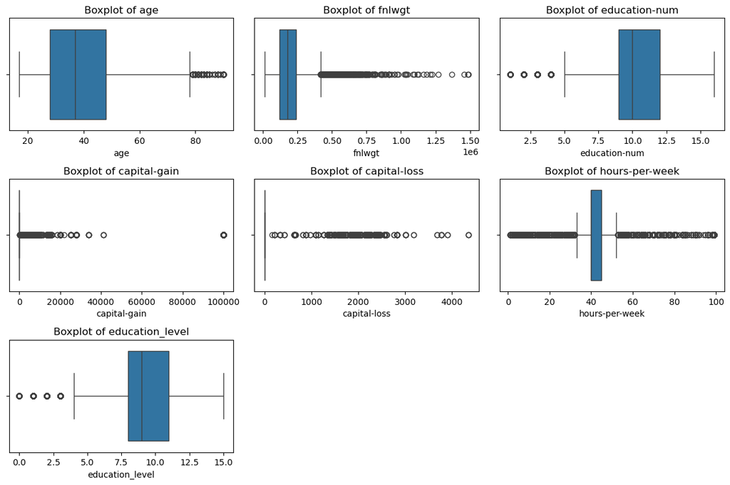

```python
def plot_feature_boxplots(data, features, n_rows=3, n_cols=3, figsize=(12, 8)):
    """
    Plots boxplots for specified features from a dataset.

    Parameters:
        data (DataFrame): The dataset containing the features.
        features (list): A list of feature names to plot.
        n_rows (int): Number of rows for the subplot grid. Default is 2.
        n_cols (int): Number of columns for the subplot grid. Default is 3.
        figsize (tuple): Size of the entire figure. Default is (12, 8).
    """
    plt.figure(figsize=figsize)

    for i, feature in enumerate(features, 1):
        plt.subplot(n_rows, n_cols, i)
        sns.boxplot(x=data[feature])
        plt.title(f'Boxplot of {feature}')

    plt.tight_layout()
    plt.show()

features = ['age', 'fnlwgt', 'education-num', 'capital-gain', 'capital-loss', 'hours-per-week','education_level']
plot_feature_boxplots(X_after_cleaned, features)
```

- Quan sát đồ thị `boxplot` của các thuộc tính, tôi nhận thấy:
  - Thuộc tính `education-num` và `education_level` có phạm vi giá trị nhỏ và không có nhiều ngoại lệ nên tôi sẽ sử dụng **Min-Max Scaling** để chuẩn hoá.
  - Thuộc tính `age` có phạm vị giá trị nhỏ và có khá nhiều ngoại lệ nên tôi sẽ sử dụng **Z-score Standardization** để chuẩn hoá.
  - Thuộc tính capital-gain và capital-loss có phạm vi giá trị rất lớn và chứa nhiều ngoại lệ. Ban đầu, Robust Scaling có vẻ phù hợp để chuẩn hoá, tuy nhiên, dữ liệu của hai thuộc tính này tập trung quanh một giá trị cố định, dẫn đến IQR xấp xỉ bằng 0. Do đó, tôi quyết định sử dụng Z-score Standardization để chuẩn hóa nhằm khắc phục vấn đề này.
  - Thuộc tính `fnlwgt` có phạm vi giá trị lớn và có rất nhiều ngoại lệ nên dùng **Robust Scaling** để chuẩn hoá.
  - Thuộc tính `hours-per-week` tuy có phạm vi giá trị nhỏ nhưng lại có rất nhiều ngoại lệ ở 2 bên nên tôi sẽ sử dụng **Robust Scaling** để chuẩn hoá nhằm mục đích làm giảm tác động của ngoại lệ trong quá trình chuẩn hoá

### 4.1 Xây dựng hàm chuẩn hoá

#### Min-Max Scaling

$$ X_{\text{scaled}} = \frac{X - X_{\text{min}}}{X_{\text{max}} - X_{\text{min}}} \times (X_{\text{max new}} - X_{\text{min new}}) + X_{\text{min new}} $$

Trong đó:

- $X$: giá trị ban đầu của feature. -$X_{\text{min}}$: giá trị nhỏ nhất của feature.
- $X_{\text{max}}$: giá trị lớn nhất của feature.
- $X_{\text{max new}}$ và $X_{\text{min new}}$: khoảng giá trị mới mong muốn sau khi chuẩn hóa (thường là ([0, 1])).

```python
# Min-Max Scaling
def min_max_scaling(df, feature, new_min=0, new_max=1):
    X = df[feature].values
    X_min = np.min(X)
    X_max = np.max(X)
    df[feature] = (df[feature] - X_min)/(X_max - X_min) * (new_max - new_min) + new_min
    # X_scaled = (X - X_min) / (X_max - X_min) * (new_max - new_min) + new_min
    # df.loc[:,feature] = X_scaled
    # df.loc[:,feature] = df[feature].astype(float)
    return df
```

#### Z-score Standardization:

$$ X_{\text{normalized}} = \frac{X - \mu}{\sigma} $$

Trong đó:

- $X$: giá trị ban đầu của feature.
- $\mu$: giá trị trung bình của feature.
- $\sigma $: độ lệch chuẩn của feature.

```python
def z_score_standardization(df, feature):
    X = df[feature].values
    mean = np.mean(X)
    std = np.std(X)
    if std == 0:
        print(f"Standard deviation is zero for feature: {feature}")
    else:
        df[feature] = (df[feature] - mean)/std
    return df
```

#### Robust Scaling

$$ X_{\text{scaled}} = \frac{X - \text{median}(X)}{\text{IQR}(X)} $$

Trong đó:

- $X$: giá trị ban đầu của feature.
- $\text{median}(X)$: trung vị của feature.
- $\text{IQR}(X) = Q_3 - Q_1$: khoảng tứ phân vị của feature, với $ Q_1 $ là phân vị thứ nhất (25%) và $Q_3$ là phân vị thứ ba (75%).

```python
# Robust Scaling
def robust_scaling(df, feature):
    X = df[feature].values
    median = np.median(X)
    Q1 = np.percentile(X, 25)
    Q3 = np.percentile(X, 75)
    IQR = Q3 - Q1
    if IQR == 0:
        print(f"IQR is zero for feature: {feature}")
    else:
        df[feature] = (df[feature] - median)/IQR
    return df
```

### 4.2 Chuẩn hoá

```python
X_after_normalize = X_after_cleaned.copy()
```

#### Chuẩn hoá thuộc tính `education-num`, `education_level` và `age`

- `education-num` :
  - Mật độ ngoại lệ: Gần như không có ngoại lệ.
  - Xử lí: Không cần thực hiện xử lý ngoại lệ vì dữ liệu khá đồng đều và không chứa giá trị ngoại lệ rõ rệt. Ap dụng Min-Max Scaling trực tiếp để chuẩn hóa.
- `age`:
  - Mật độ ngoại lệ: Có một số ngoại lệ ở phía giá trị cao.
  - Xử lý: Do mật độ ngoại lệ không quá cao, có thể giữ lại những ngoại lệ này để phản ánh sự đa dạng trong độ tuổi của mẫu dữ liệu. Sử dụng Z-score Standardization để giảm tác động của các ngoại lệ này mà không cần loại bỏ chúng.

```python
# normalize education-num by Min-Max scaling

X_after_normalize = min_max_scaling(X_after_normalize, feature= 'education-num')
X_after_normalize = min_max_scaling(X_after_normalize,feature='education_level')
# normalize age by z_score_standardization
X_after_normalize = z_score_standardization(df= X_after_normalize, feature='age')
```

#### Chuẩn hoá thuộc tính `capital-gain` và `capital-loss`

- Mật độ ngoại lệ: Rất nhiều ngoại lệ và giá trị tập trung cao quanh giá trị 0.
- Xử lý: Vì các giá trị tập trung quanh 0 và số lượng ngoại lệ quá lớn, các phương pháp loại bỏ ngoại lệ thông thường như IQR Filtering sẽ không hiệu quả. Thay vào đó:
  - Biến đổi logarit: Dùng log-transform để giảm sự chênh lệch giữa các giá trị lớn và các giá trị gần 0.
  - Z-score Standardization: Sử dụng Z-score sau khi đã biến đổi logarit để chuẩn hóa dữ liệu.

```python
X_after_normalize['capital-gain'] = np.log1p(X_after_normalize['capital-gain'])
X_after_normalize['capital-loss'] = np.log1p(X_after_normalize['capital-loss'])
X_after_normalize = z_score_standardization(df=X_after_normalize, feature='capital-gain')
X_after_normalize = z_score_standardization(df=X_after_normalize, feature='capital-loss')
```

#### Chuẩn hoá thuộc tính `fnlwgt`

- Mật độ ngoại lệ: Rất nhiều ngoại lệ ở phía giá trị cao.
- Xử lý: Vì fnlwgt có nhiều ngoại lệ nhưng phân phối dữ liệu tương đối ổn định ở phần trung tâm, ta có thể:
  - Giới hạn giá trị tối đa: Cắt bớt các giá trị cực lớn (cap at the 95th percentile) để giảm ảnh hưởng của các ngoại lệ nghiêm trọng.
  - Sau đó, áp dụng Robust Scaling để chuẩn hóa.

```python
#q95_fnlwgt = X_after_normalize['fnlwgt'].quantile(0.95)
q95_fnlwgt = np.percentile(X_after_normalize['fnlwgt'],95)
X_after_normalize['fnlwgt'] = np.where(X_after_normalize['fnlwgt'] > q95_fnlwgt, q95_fnlwgt, X_after_normalize['fnlwgt'])
X_after_normalize = robust_scaling(df= X_after_normalize, feature='fnlwgt')
```

#### Chuẩn hoá thuộc tính `hours-per-week`

- Mật độ ngoại lệ: Nhiều ngoại lệ ở cả hai phía cao và thấp.
- Xử lý:
  - Giới hạn giá trị: Để giảm bớt ảnh hưởng của những giờ làm việc bất thường, có thể cắt các giá trị cao/thấp quá mức (ví dụ, cắt ở 5th và 95th percentile).
  - Robust Scaling: Sau khi đã loại bỏ các giá trị ngoại lệ quá cao hoặc quá thấp, áp dụng Robust Scaling để chuẩn hóa giá trị giờ làm việc.

```python
#q5_hours = X_after_normalize['hours-per-week'].quantile(0.05)
q5_hours = np.percentile(X_after_normalize['hours-per-week'],5)
#q95_hours = X_after_normalize['hours-per-week'].quantile(0.95)
q95_hours = np.percentile(X_after_normalize['hours-per-week'],95)
X_after_normalize['hours-per-week'] = np.clip(X_after_normalize['hours-per-week'], q5_hours, q95_hours)
X_after_normalize = robust_scaling(df=X_after_normalize, feature= 'hours-per-week')
```

**Biểu diễn trực quan boxplot của các thuộc tính sau khi chuẩn hoá**

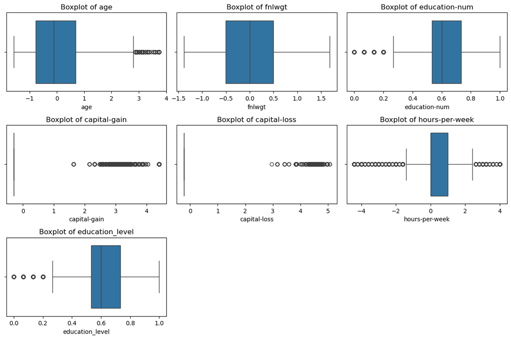

```python
features = ['age', 'fnlwgt', 'education-num', 'capital-gain', 'capital-loss', 'hours-per-week','education_level']
plot_feature_boxplots(X_after_normalize, features)
```

## 5.Feature selection - Chọn thuộc tính

```python
X_after_selection_feature = X_after_normalize.copy()
```

### 5.1 Sử dụng Correlation Thresholding

**Tính ma trận tương quan và trực quan hoá ma trận tương quan**

```python
features = X_after_normalize.columns  # Lấy tên các cột của DataFrame X
# Tính ma trận tương quan bằng numpy
corr_matrix = np.corrcoef(X_after_normalize.values.T)

# Vẽ heatmap biểu diễn ma trận tương quan
plt.figure(figsize=(100, 100))
sns.heatmap(corr_matrix, annot=True, fmt=".2f", cmap="coolwarm", xticklabels=features, yticklabels=features)
plt.title("Correlation Matrix Heatmap")
plt.show()
```

[figure not shown]

**Chọn thuộc tính**

```python
threshold = 0.8  # Ngưỡng tương quan



# Tìm các cặp thuộc tính có hệ số tương quan lớn hơn threshold
high_corr_pairs = np.where(np.abs(corr_matrix) > threshold)
high_corr = [(features[x], features[y]) for x, y in zip(*high_corr_pairs) if x != y and x < y]

# In ra các cặp thuộc tính có hệ số tương quan cao
print("Các cặp thuộc tính có hệ số tương quan cao hơn", threshold, "là:")
for pair in high_corr:
    print(pair)
```

```
Các cặp thuộc tính có hệ số tương quan cao hơn 0.8 là:
('Married', 'Husband')
('education_level', 'education-num')
```

Các cặp thuộc tính có tương quan mạnh với nhau là: cặp (`Married`,`Husband`) và cặp (`education_level`,`education-num`). Tôi sẽ xoá thuộc tính `Husband` và `education-num`

```python
X_after_selection_feature = X_after_selection_feature.drop(columns=['education-num'])
X_after_selection_feature = X_after_selection_feature.drop(columns=['Husband'])
```

### 5.2 Sử dụng Variance Inflation Factor

**Variance Inflation Factor (VIF)** là một chỉ số được sử dụng để đo lường mức độ đa cộng tuyến (multicollinearity) giữa các biến độc lập trong mô hình hồi quy tuyến tính. Đa cộng tuyến xảy ra khi một hoặc nhiều biến độc lập có mối quan hệ quá chặt chẽ với nhau, điều này có thể làm giảm độ chính xác và khả năng giải thích của mô hình.

#### Nguyên lý của VIF

VIF cho biết mức độ quan hệ giữa một biến độc lập và các biến độc lập khác trong mô hình. Giá trị VIF càng cao, càng có nhiều đa cộng tuyến giữa biến đó và các biến khác, điều này có thể gây ra sai lệch trong ước lượng các hệ số của mô hình.

Công thức tính VIF cho một biến độc lập $X_i$ như sau:

$ \text{VIF}(X_i) = \frac{1}{1 - R^2_i} $

Trong đó:

- $R^2_i$ là hệ số xác định (R-squared) khi biến độc lập $X_i$ được hồi quy trên tất cả các biến độc lập khác trong mô hình.

#### Các bước tính VIF cho một biến

1. **Hồi quy biến $X_i$ lên các biến còn lại**: Hồi quy $X_i$ lên tất cả các biến độc lập còn lại và tính giá trị $R^2$.
2. **Tính VIF**: Sử dụng công thức $\text{VIF} = \frac{1}{1 - R^2}$ để tính VIF cho biến $X_i$.

#### Ý nghĩa của VIF

- **VIF = 1**: Biến độc lập $X_i$ không có mối quan hệ tuyến tính với các biến độc lập khác. Không có đa cộng tuyến, biến này độc lập.
- **1 < VIF < 5**: Có mối quan hệ vừa phải giữa biến $X_i$ và các biến độc lập khác. Mặc dù có đa cộng tuyến nhẹ, mô hình vẫn có thể ổn.
- **VIF > 5 (hoặc 10)**: Có sự đa cộng tuyến mạnh giữa biến $X_i$ và các biến khác. Điều này có thể làm cho mô hình không ổn định và kết quả không chính xác. Trong trường hợp này, nên cân nhắc loại bỏ hoặc kết hợp các biến.

#### Xây dựng hàm tính VIF cho từng cột

```python
# Hàm tính VIF cho từng cột trong X
def calculate_vif(X):
    vif_values = []

    # Duyệt qua từng cột trong DataFrame
    for i in range(X.shape[1]):
        # Xác định các cột không phải cột thứ i
        X_except_i = X.drop(X.columns[i], axis=1)
        target = X.iloc[:, i]

        # Tính hệ số hồi quy R^2 bằng cách sử dụng hàm số từ numpy
        coef = np.linalg.lstsq(X_except_i, target, rcond=None)[0]
        predicted = X_except_i @ coef
        r_squared = 1 - (np.sum((target - predicted) ** 2) / np.sum((target - np.mean(target)) ** 2))

        # Kiểm tra nếu r_squared = 1 (để tránh chia cho 0)
        if r_squared == 1:
            vif = np.inf  # Đặt VIF là vô cùng khi có đa cộng tuyến hoàn toàn
        else:
            # Tính VIF cho thuộc tính thứ i
            vif = 1 / (1 - r_squared)

        vif_values.append(vif)

    return np.array(vif_values)

# Sử dụng ngưỡng VIF (thường là 10) để loại bỏ các cột có đa cộng tuyến cao
vif_threshold = 10
# Khởi tạo một DataFrame chứa các biến
X_selected = X_after_selection_feature.copy()

# Lặp lại cho đến khi không còn biến nào có VIF vượt ngưỡng
while True:
    vif_values = calculate_vif(X_selected)  # Tính VIF cho các biến hiện tại
    max_vif = vif_values.max()  # Tìm VIF cao nhất

    if max_vif > vif_threshold:
        # Xác định cột có VIF cao nhất và loại bỏ
        max_vif_index = vif_values.argmax()
        column_to_drop = X_selected.columns[max_vif_index]
        print(f"Loại bỏ cột '{column_to_drop}' với VIF = {max_vif}")
        X_selected = X_selected.drop(columns=[column_to_drop])
    else:
        # Kết thúc nếu tất cả VIF đều dưới ngưỡng
        break
columns_to_keep = X_selected.columns
print("Các cột được giữ lại sau khi kiểm tra VIF:",columns_to_keep)
```

```
Loại bỏ cột 'Married' với VIF = inf
Loại bỏ cột 'Management' với VIF = inf
Loại bỏ cột 'White' với VIF = inf
Loại bỏ cột 'Never-married' với VIF = 12.186487217307683
Các cột được giữ lại sau khi kiểm tra VIF: Index(['is Male', 'Separated', 'Widowed', 'Divorced', 'education_level',
       'Technical', 'Service', 'Office', 'Armed-Forces', 'Not-in-family',
       'Own-child', 'Unmarried', 'Wife', 'Other-relative', 'Black',
       'Asian-Pac-Islander', 'Amer-Indian-Eskimo', 'Other race', 'is-USA',
       'Private', 'Self-emp-not-inc', 'Local-gov', 'State-gov', 'Self-emp-inc',
       'Federal-gov', 'Other workclass', 'age', 'fnlwgt', 'capital-gain',
       'capital-loss', 'hours-per-week'],
      dtype='object')
```

```python
X_after_selection_feature = X_after_selection_feature[columns_to_keep]
```

```python
X_after_selection_feature.columns
```

```
Index(['is Male', 'Separated', 'Widowed', 'Divorced', 'education_level',
       'Technical', 'Service', 'Office', 'Armed-Forces', 'Not-in-family',
       'Own-child', 'Unmarried', 'Wife', 'Other-relative', 'Black',
       'Asian-Pac-Islander', 'Amer-Indian-Eskimo', 'Other race', 'is-USA',
       'Private', 'Self-emp-not-inc', 'Local-gov', 'State-gov', 'Self-emp-inc',
       'Federal-gov', 'Other workclass', 'age', 'fnlwgt', 'capital-gain',
       'capital-loss', 'hours-per-week'],
      dtype='object')
```

### 5.3 Sử dụng Variance threshold

- `Variance Threshold` là một phương pháp feature selection dựa trên nguyên lý rằng các thuộc tính có phương sai thấp không cung cấp nhiều thông tin để phân biệt giữa các mẫu.
  - Nguyên lý chính: Các thuộc tính có phương sai rất thấp (tức là gần như không thay đổi giá trị) không đóng góp nhiều vào quá trình phân loại hoặc dự đoán vì chúng không thể phân biệt các điểm dữ liệu khác nhau.
  - Cách hoạt động: Lọc bỏ các thuộc tính có phương sai thấp hơn một ngưỡng nhất định (threshold). Các thuộc tính này ít thay đổi giữa các mẫu, nên thường không mang lại giá trị thông tin cho mô hình.

```python
# Giả sử X là DataFrame chứa dữ liệu và threshold là ngưỡng phương sai
threshold = 0.01

# Chuyển DataFrame sang numpy array
X_values = X_after_selection_feature.values

# Tính phương sai của từng cột
variances = np.var(X_values, axis=0)
# Lấy tên các cột có phương sai lớn hơn ngưỡng
high_variance_columns = X_after_selection_feature.columns[variances > threshold]
print("Tên các cột có phương sai thấp (nên loại bỏ):", X_after_selection_feature.columns[variances <= threshold].tolist())
# Lọc các cột có phương sai cao từ DataFrame X
X_after_selection_feature = X_after_selection_feature[high_variance_columns]
```

```
Tên các cột có phương sai thấp (nên loại bỏ): ['Armed-Forces', 'Amer-Indian-Eskimo', 'Other race', 'Other workclass']
```

```python
X_after_selection_feature.columns
```

```
Index(['is Male', 'Separated', 'Widowed', 'Divorced', 'education_level',
       'Technical', 'Service', 'Office', 'Not-in-family', 'Own-child',
       'Unmarried', 'Wife', 'Other-relative', 'Black', 'Asian-Pac-Islander',
       'is-USA', 'Private', 'Self-emp-not-inc', 'Local-gov', 'State-gov',
       'Self-emp-inc', 'Federal-gov', 'age', 'fnlwgt', 'capital-gain',
       'capital-loss', 'hours-per-week'],
      dtype='object')
```

### 5.4 Mutual Information

#### 1. Nguyên lý của Mutual Information cho Feature Selection

**Mutual Information (MI)** đo lường mức độ thông tin mà một thuộc tính (feature) cung cấp về nhãn mục tiêu (target). MI giúp xác định các thuộc tính có mối quan hệ phụ thuộc với nhãn mục tiêu. Những thuộc tính có MI cao với nhãn mục tiêu sẽ chứa nhiều thông tin phân biệt và thường có ý nghĩa hơn trong bài toán phân loại.

##### Công thức tính Mutual Information

Mutual Information $ MI(X; Y)$ giữa thuộc tính $ X $ và nhãn mục tiêu $Y$ được tính bằng: $$ MI(X; Y) = H(Y) - H(Y | X) $$

- $H(Y)$: Entropy của nhãn mục tiêu $Y$, đo lường sự không chắc chắn của $Y$.
- $H(Y | X)$: Entropy có điều kiện của $ Y $ khi biết giá trị của $ X $, đo lường sự không chắc chắn còn lại của $ Y $ khi đã biết $X $.

MI càng lớn, thuộc tính $X$ càng cung cấp nhiều thông tin về $Y$, và do đó thường hữu ích cho phân loại.

### Công thức tính Entropy

Entropy $ H(Y) $ của một nhãn mục tiêu $Y $ được tính bằng: $$ H(Y) = - \sum_{i=1}^n P(y_i) \log_2 P(y_i) $$ với:

- $P(y_i)$: Xác suất của từng giá trị có thể có của $Y $.

Entropy có điều kiện $H(Y | X)$ được tính tương tự, nhưng có điều kiện dựa trên các giá trị của $ X $.

#### 2. Giải thuật sử dụng Mutual Information cho việc chọn thuộc tính

Dưới đây là các bước của giải thuật tính Mutual Information cho mỗi thuộc tính với nhãn mục tiêu trong Jupyter Notebook:

1. **Tính Entropy của nhãn mục tiêu $ Y $**:
   - Sử dụng công thức Entropy để tính $ H(Y) $, đo lường mức độ không chắc chắn của nhãn mục tiêu.
2. **Tính Entropy có điều kiện cho từng thuộc tính**:
   - Với mỗi thuộc tính $ X $, tính toán Entropy có điều kiện $ H(Y | X) $. Đối với mỗi giá trị của $X$, tính Entropy của $ Y$ và tính trung bình có trọng số dựa trên xác suất xuất hiện của mỗi giá trị trong $ X $.
3. **Tính Mutual Information**:
   - Với mỗi thuộc tính $X$, tính MI bằng công thức $ MI(X; Y) = H(Y) - H(Y | X) $.
   - Lưu trữ giá trị MI cho từng thuộc tính.
4. **Lọc các thuộc tính**:
   - Đặt ngưỡng để chọn các thuộc tính có MI lớn hơn một giá trị nhất định. Các thuộc tính có MI cao sẽ giữ lại cho mô hình phân loại vì chúng cung cấp nhiều thông tin về nhãn mục tiêu.

```python
# Hàm tính Entropy của một thuộc tính
def entropy(y):
    hist = np.bincount(y)
    prob = hist / len(y)
    return -np.sum([p * np.log2(p) for p in prob if p > 0])

# Hàm tính Mutual Information giữa từng thuộc tính và nhãn mục tiêu
def mutual_information(X, target):
    mi = []
    H_y = entropy(target)  # Entropy của nhãn mục tiêu
    for i in range(X.shape[1]):
        values, counts = np.unique(X[:, i], return_counts=True)
        H_y_given_x = 0
        for v, c in zip(values, counts):
            H_y_given_x += (c / len(target)) * entropy(target[X[:, i] == v])
        # MI = H(y) - H(y | x)
        mi.append(H_y - H_y_given_x)
    return np.array(mi)

# Chuyển DataFrame sang numpy array và tách cột target
X_values = X_after_selection_feature.values
target = y['is >50K'].values

# Tính Mutual Information cho từng thuộc tính
mi_scores = mutual_information(X_values, target)
```

```python
mi_scores
```

```
array([3.66945869e-02, 5.03824913e-03, 3.76997477e-03, 1.39050150e-02,
       9.21266099e-02, 1.05799318e-02, 1.84030482e-02, 2.88804934e-03,
       2.96802992e-02, 5.34462382e-02, 1.90339419e-02, 9.08152630e-03,
       7.43592618e-03, 6.74949219e-03, 1.11784013e-04, 1.08731546e-03,
       1.06195257e-02, 5.11069130e-04, 7.60796557e-04, 1.25952226e-04,
       1.17379857e-02, 2.43000847e-03, 9.79420328e-02, 4.82804670e-01,
       1.19616365e-01, 5.33060828e-02, 5.82817008e-02])
```

**Chọn thuộc tính**

```python
# In ra các giá trị MI và chọn các cột có MI cao hơn một ngưỡng
threshold = 0.05
# Lấy tên các thuộc tính từ DataFrame
feature_names = X_after_selection_feature.columns


selected_features = feature_names[mi_scores > threshold]

selected_features = selected_features.tolist()

X_after_selection_feature = X_after_selection_feature[selected_features]
```

**Các cột được chọn**

```python
X_after_selection_feature.columns
```

```
Index(['education_level', 'Own-child', 'age', 'fnlwgt', 'capital-gain',
       'capital-loss', 'hours-per-week'],
      dtype='object')
```

## 6. Data Discretization

### 6.1 Quan sát histogram của các thuộc tính liên tục trước khi rời rạc hoá

```python
X_after_discretize = X_after_selection_feature.copy()
```

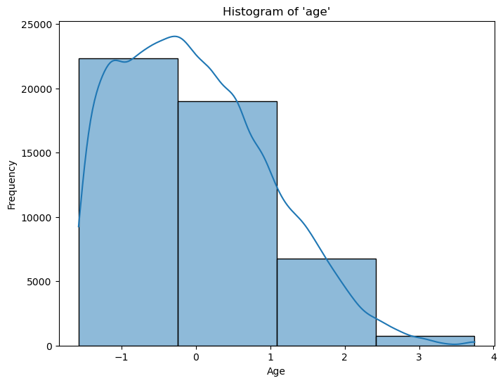

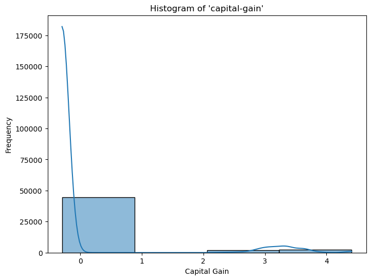

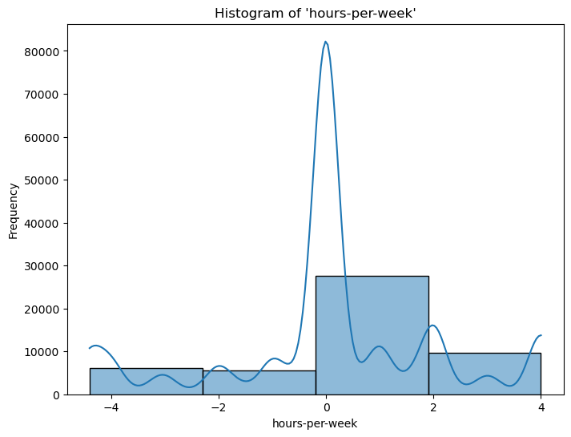

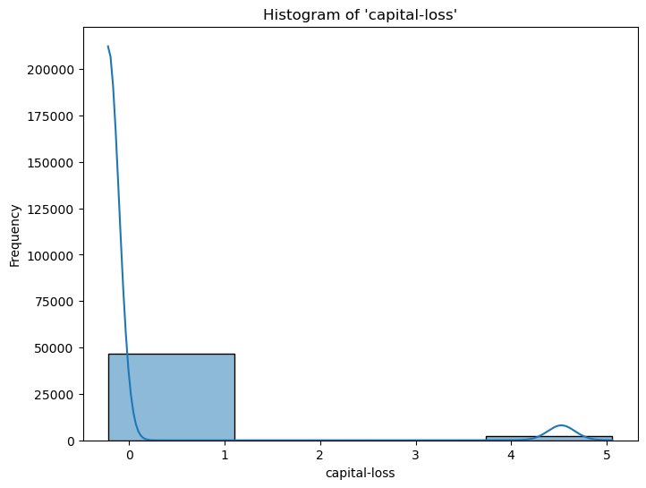

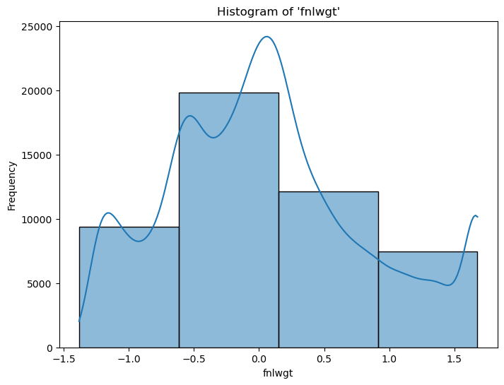

```python
# Vẽ histogram cho thuộc tính 'age' trong DataFrame X
plt.figure(figsize=(8, 6))
sns.histplot(X_after_selection_feature['age'], bins=4, kde=True)
plt.title("Histogram of 'age'")
plt.xlabel("Age")
plt.ylabel("Frequency")
plt.show()

# Vẽ histogram cho thuộc tính 'capital-gain' trong DataFrame X
plt.figure(figsize=(8, 6))
sns.histplot(X_after_selection_feature['capital-gain'], bins=4, kde=True)
plt.title("Histogram of 'capital-gain'")
plt.xlabel("Capital Gain")
plt.ylabel("Frequency")
plt.show()


# Vẽ histogram cho thuộc tính 'capital-gain' trong DataFrame X
plt.figure(figsize=(8, 6))
sns.histplot(X_after_selection_feature['hours-per-week'], bins=4, kde=True)
plt.title("Histogram of 'hours-per-week'")
plt.xlabel("hours-per-week")
plt.ylabel("Frequency")
plt.show()



# Vẽ histogram cho thuộc tính 'capital-gain' trong DataFrame X
plt.figure(figsize=(8, 6))
sns.histplot(X_after_selection_feature['capital-loss'], bins=4, kde=True)
plt.title("Histogram of 'capital-loss'")
plt.xlabel("capital-loss")
plt.ylabel("Frequency")
plt.show()


# Vẽ histogram cho thuộc tính 'capital-gain' trong DataFrame X
plt.figure(figsize=(8, 6))
sns.histplot(X_after_selection_feature['fnlwgt'], bins=4, kde=True)
plt.title("Histogram of 'fnlwgt'")
plt.xlabel("fnlwgt")
plt.ylabel("Frequency")
plt.show()
```

### 6.2 Xây dựng hàm binning

```python
# Hàm Equal-width Binning
def equal_width_binning(data, num_bins):
    min_val, max_val = np.min(data), np.max(data)
    bins = np.linspace(min_val, max_val, num_bins + 1)  # Tạo ra các ngưỡng phân chia
    discretized = np.digitize(data, bins) - 1  # Đặt vào các nhóm
    return discretized

# Hàm Equal-depth Binning
def equal_depth_binning(data, num_bins):
    quantiles = np.linspace(0, 1, num_bins + 1)
    bins = np.quantile(data, quantiles)  # Tạo các ngưỡng dựa trên tần số
    discretized = np.digitize(data, bins, right=True) - 1
    return discretized
```

**Rời rạc hoá:**

```python
num_bins = 4
age_discretized = equal_width_binning(X_after_discretize['age'].values, num_bins)
X_after_discretize['age_discretized'] = age_discretized
capital_gain_discretized = equal_depth_binning(X_after_discretize['capital-gain'].values, num_bins)
X_after_discretize['capital-gain_discretized'] = capital_gain_discretized
capital_loss_discretized = equal_depth_binning(X_after_discretize['capital-loss'].values, num_bins)
X_after_discretize['capital-loss_discretized'] = capital_loss_discretized
hours_per_week_discretized = equal_depth_binning(X_after_discretize['hours-per-week'].values, num_bins)
X_after_discretize['hours-per-week_discretized'] = hours_per_week_discretized

fnlwgt_discretized = equal_width_binning(X_after_discretize['fnlwgt'].values, num_bins)
X_after_discretize['fnlwgt_discretized'] = fnlwgt_discretized
X_after_discretize = X_after_discretize[['age_discretized','capital-gain_discretized','capital-loss_discretized','hours-per-week_discretized','fnlwgt_discretized','education_level', 'Own-child']]
```

**Kiểm tra các cột sau khi được rời rạc hoá**

```python
X_after_discretize['age_discretized'].value_counts()
```

```
age_discretized
0    22326
1    19004
2     6732
3      695
4       54
Name: count, dtype: int64
```

```python
X_after_discretize['capital-gain_discretized'].value_counts()
```

```
capital-gain_discretized
-1    44776
 3     4035
Name: count, dtype: int64
```

```python
X_after_discretize['capital-loss_discretized'].value_counts()
```

```
capital-loss_discretized
-1    46529
 3     2282
Name: count, dtype: int64
```

```python
X_after_discretize['fnlwgt_discretized'].value_counts()
```

```
fnlwgt_discretized
1    19825
2    12152
0     9377
3     5016
4     2441
Name: count, dtype: int64
```

```python
X_after_discretize['hours-per-week_discretized'].value_counts()
```

```
hours-per-week_discretized
 0    31898
 3    10697
 2     3650
-1     2566
Name: count, dtype: int64
```

```python
print('Giá trị có thể có ở cột age_discretized sau khi chuẩn hoá và rời rạc hoá là:', X_after_discretize['age_discretized'].unique())
print('Giá trị có thể có ở cột capital-gain_discretized sau khi chuẩn hoá và rời rạc hoá là:', X_after_discretize['capital-gain_discretized'].unique())
print('Giá trị có thể có ở cột capital-loss_discretized sau khi chuẩn hoá và rời rạc hoá là:', X_after_discretize['capital-loss_discretized'].unique())
print('Giá trị có thể có ở cột hours-per-week_discretized sau khi chuẩn hoá và rời rạc hoá là:', X_after_discretize['hours-per-week_discretized'].unique())
print('Giá trị có thể có ở cột fnlwgt_discretized sau khi chuẩn hoá và rời rạc hoá là:', X_after_discretize['fnlwgt_discretized'].unique())
```

```
Giá trị có thể có ở cột age_discretized sau khi chuẩn hoá và rời rạc hoá là: [1 0 2 3 4]
Giá trị có thể có ở cột capital-gain_discretized sau khi chuẩn hoá và rời rạc hoá là: [ 3 -1]
Giá trị có thể có ở cột capital-loss_discretized sau khi chuẩn hoá và rời rạc hoá là: [-1  3]
Giá trị có thể có ở cột hours-per-week_discretized sau khi chuẩn hoá và rời rạc hoá là: [ 0 -1  2  3]
Giá trị có thể có ở cột fnlwgt_discretized sau khi chuẩn hoá và rời rạc hoá là: [0 2 3 1 4]
```

### 6.3 Trực quan hoá các thuộc tính sau khi rời rạc hoá

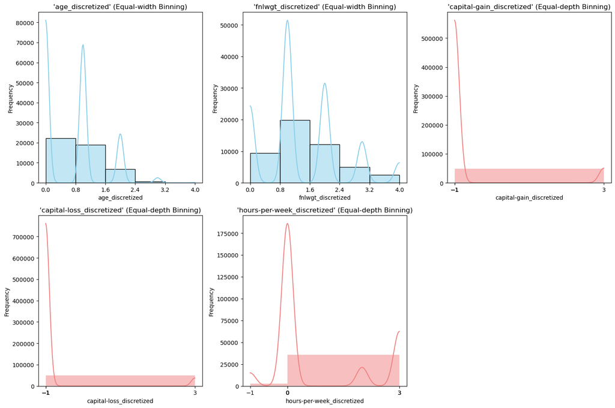

```python
# Hàm vẽ histogram cho từng thuộc tính với các phương pháp rời rạc hóa khác nhau
def plot_discretized_histograms(df, columns_width, columns_depth, n_bins=5):
    plt.figure(figsize=(15, 10))
    plot_index = 1

    # Vẽ histogram cho các cột dùng phương pháp Equal-width Binning
    for column in columns_width:
        # Tính các khoảng giá trị theo Equal-width Binning
        col_min, col_max = df[column].min(), df[column].max()
        bin_width = (col_max - col_min) / n_bins
        equal_width_bins = np.linspace(col_min, col_max, n_bins + 1)

        # Vẽ histogram cho cột
        plt.subplot(2, 3, plot_index)
        sns.histplot(df[column], bins=equal_width_bins, kde=True, color='skyblue')
        plt.title(f"'{column}' (Equal-width Binning)")
        plt.xlabel(column)
        plt.ylabel("Frequency")
        plt.xticks(equal_width_bins.round(2))  # Đặt ngưỡng giá trị trên trục x

        plot_index += 1

    # Vẽ histogram cho các cột dùng phương pháp Equal-depth Binning
    for column in columns_depth:
        # Tính các khoảng giá trị theo Equal-depth Binning
        equal_depth_bins = np.percentile(df[column], np.linspace(0, 100, n_bins + 1))

        # Vẽ histogram cho cột
        plt.subplot(2, 3, plot_index)
        sns.histplot(df[column], bins=equal_depth_bins, kde=True, color='lightcoral')
        plt.title(f"'{column}' (Equal-depth Binning)")
        plt.xlabel(column)
        plt.ylabel("Frequency")
        plt.xticks(equal_depth_bins.round(2))  # Đặt ngưỡng giá trị trên trục x

        plot_index += 1

    plt.tight_layout()
    plt.show()

# Sử dụng DataFrame X_after_selection_feature để vẽ histogram
columns_width = ['age_discretized', 'fnlwgt_discretized']
columns_depth = ['capital-gain_discretized', 'capital-loss_discretized', 'hours-per-week_discretized']

plot_discretized_histograms(X_after_discretize, columns_width, columns_depth, n_bins=5)
```

## Tổng kết

```python
X_after_discretize.head(5)
```

|  | age_discretized | capital-gain_discretized | capital-loss_discretized | hours-per-week_discretized | fnlwgt_discretized | education_level | Own-child |
| --- | --- | --- | --- | --- | --- | --- | --- |
| 0 | 1 | 3 | -1 | 0 | 0 | 0.800000 | 0 |
| 1 | 1 | -1 | -1 | -1 | 0 | 0.800000 | 0 |
| 2 | 1 | -1 | -1 | 0 | 2 | 0.533333 | 0 |
| 3 | 1 | -1 | -1 | 0 | 2 | 0.400000 | 0 |
| 4 | 0 | -1 | -1 | 0 | 3 | 0.800000 | 0 |

- **Quan sát tập dữ liệu y sau khi tiền xử lí:**

```python
y['is >50K'].head(10)
```

```
0    0
1    0
2    0
3    0
4    0
5    0
6    0
7    1
8    1
9    1
Name: is >50K, dtype: int64
```